# Simulating fossils

### Environment and lineage-dependent fossil recovery

Lineage specific values generated using `sim.trait.values` can also be passed to the the function `sim.fossils.environment` to define the `PD`, `DT`, and `PA` parameters.

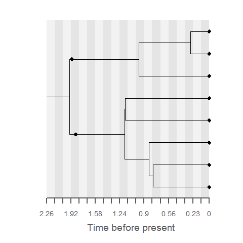

```r
# define constant values for preferred depth and depth tolerance
PD = 2
DT = 0.5

# simulate lineage variable peak abundance values

# define the distribution used to sample new PA values
# in this case a uniform in the interval 0, 1
dist = function() { runif(1) }

# simulate trait values under the independent model
PA = sim.trait.values(init = 0.1, tree = t, model = "independent", dist = dist)

# simulate fossils
f = sim.fossils.environment(tree = t, interval.ages = times, proxy.data = wd, PD = PD, DT = DT, PA = PA)

# plot the output
plot(f, tree = t, show.strata = TRUE, interval.ages = times)
```

## Extant species and tip sampling

The functions `sim.extant.samples` and `sim.tip.samples` can be used to simulate incomplete extant species and tip sampling, respectively. The parameter `rho` is the probability that an extant species or a tip will be sampled.

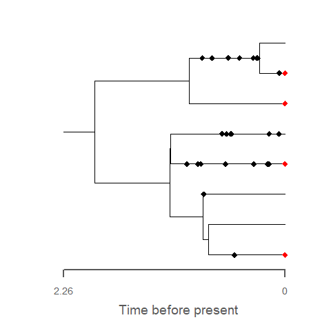

```r
# simulate fossils
f = sim.fossils.poisson(tree = t, rate = rates)

# simulate extant species sampling
f2 = sim.extant.samples(fossils = f, tree = t, rho = 0.5)

# plot the output
plot(f2, tree = t, extant.col = "red")
```

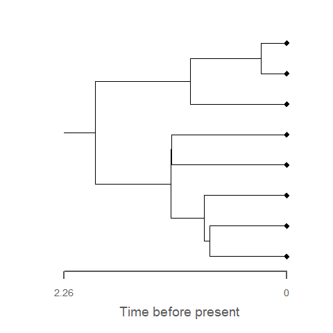

```r
# for tip sampling only, create a fossil object with no fossils
f = fossils()

# simulate tip sampling
f2 = sim.tip.samples(fossils = f, tree = t, rho = 0.75)

# plot the output
plot(f2, tree = t)
```

## See also

See the `paleotree` vignette to see how `FossilSim` objects can be converted into `paleotree` objects.

## References

Heath, T.A., Huelsenbeck, J.P. & Stadler, T. (2014). [The fossilized birth-death process for coherent calibration of divergence-time estimates](https://doi.org/10.1073/pnas.1319091111). *Proceedings of the National Academy of Sciences*, **111**, E2957–E2966.

Holland, S.M. (1995). [The stratigraphic distribution of fossils](https://doi.org/10.1017/S0094837300013099). *Paleobiology*, **21**, 92–109.

Kishino, H., Thorne, J.L. & Bruno, W.J. (2001). Performance of a divergence time estimation method under a probabilistic model of rate evolution. *Molecular Biology and Evolution*, **18**, 352–361.